# Exploring simulations

Author

Max, Jim, Sean

Published

2024-05-16

```r
# Load libraries
library(tidyr)
library(dplyr)
library(patchwork)
library(RColorBrewer)
library(readr)
library(terra) # Load terra to use extract... needed for prep-data
library(ggtext)
library(ggstats)
library(ggdist)
library(ggplot2)
library(ggsidekick); theme_set(theme_sleek())
```

## Simulate data

### Cross-experiment with diffusion and null model for simulating data and retrieving parameters

- Simulate from yellowfin model
- Vary sigma and the diffusion parameters. How well can we retrieve them?
- How well can we get the correct model with AIC?

#### Fit a model to adult yellowfin sole

… To get a feeling for some sensible starting values for parameters and to get a model to simulate form

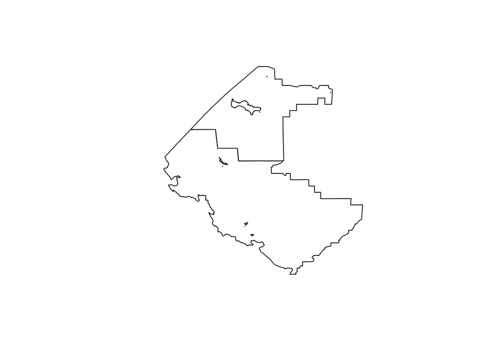

```r
source(here::here("analysis/prep-data.R"))
```

```r
setwd(tmb_dir)
compile("movement_kernel_sim.cpp", framework = "TMBad")
dyn.load(dynlib("movement_kernel_sim"))
# dyn.unload(dynlib("movement_kernel"))
```

```r
species_set <- colnames(region_data_all)[30:ncol(region_data_all)]
N_c <- colSums(ifelse(region_data_all[, species_set] > 0, 1, 0))
species_set <- species_set[N_c > 1000]

param_set <- c("obj_diffusion", "obj_null", "deltaAIC", "range", "ln_kappa2", "corr_depth")

cI <- match("a_yfs", species_set)
species <- species_set[cI]

f_depth
```

```
[1] "identity"
```

```r
if (f_depth == "identity") {
  depthprime_s <- (depth_s / 100)
  #depthprime_s <- (depth_s - mean(depth_s)) / sd(depth_s) # ML: Can we better estimate depth and depth sq if we square?
  #depthprime_s <- (log(depth_s) - mean(log(depth_s))) / sd(log(depth_s)) # ML: Can we better estimate depth and depth sq if we square?
} else if (f_depth == "log") {
  depthprime_s <- log(depth_s) - 4.5
}

# cor(depthprime_s, depthprime_s^2)
# depthprime_scaled <- (log(depth_s) - mean(log(depth_s))) / sd(log(depth_s)) # ML: Can we better estimate depth and depth sq if we square?
# cor(depthprime_scaled, depthprime_scaled^2)

Params <- list(
  "beta0" = 0,
  #"beta_j" = c(0.1, 0.1),
  "beta_j" = 0.1,
  "ln_tau" = 0,
  "ln_kappa" = 0,
  "omega_s" = rnorm(nrow(spde$c0)),
  "ln_kappa2" = exp(-1)
)

Random <- "omega_s"

# Special stuff
#if (Data$dist == "LNP") {
Params$ln_sigma_eta <- log(0.1)
Params$eta_i <- rnorm(nrow(region_data_all))
Random <- c(Random, "eta_i")
```

##### Diffusion estimation model

```r
Data_sim_diff <- list(
  "method" = "diffusion",
  "dist" = distribution,
  "c_i" = region_data_all[, species],
  "A_is" = A_is,
  "A_gs" = A_gs,
  "M0" = spde$c0,
  "M1" = spde$g1,
  "M2" = spde$g2,
  "invsqrtM0" = invsqrtM0,
  "invM0" = invM0,
  "depth_s" = depthprime_s,
  "sim_gmrf" = 1L #< new
)

Obj_sim_diff <- MakeADFun(
  data = Data_sim_diff,
  parameters = Params,
  # profile = c("beta0","beta_j"),    # ,"ln_kappa2"
  random = Random,
  checkParameterOrder = TRUE,
  DLL = "movement_kernel_sim"
)

Obj_sim_diff$env$beSilent()

# Optimize
Opt_sim_diff <- nlminb(
  start = Obj_sim_diff$par,
  obj = Obj_sim_diff$fn,
  grad = Obj_sim_diff$gr,
  control = list(eval.max = 1e4, iter.max = 1e4, trace = 1)
)
```

##### Null estimation model

```r
Data_sim_null <- list(
  "method" = "null",
  "dist" = distribution,
  "c_i" = region_data_all[, species],
  "A_is" = A_is,
  "A_gs" = A_gs,
  "M0" = spde$c0,
  "M1" = spde$g1,
  "M2" = spde$g2,
  "invsqrtM0" = invsqrtM0,
  "invM0" = invM0,
  "depth_s" = depthprime_s,
  "sim_gmrf" = 1L #< new
)

Obj_sim_null <- MakeADFun(
  data = Data_sim_null,
  parameters =  Params[setdiff(names(Params), c("ln_tau2","ln_kappa2"))],
  # profile = c("beta0","beta_j"),    # ,"ln_kappa2"
  random = Random,
  checkParameterOrder = TRUE,
  DLL = "movement_kernel_sim"
)
Obj_sim_null$env$beSilent()

# Optimize
Opt_sim_null <- nlminb(
  start = Obj_sim_null$par,
  obj = Obj_sim_null$fn,
  grad = Obj_sim_null$gr,
  control = list(eval.max = 1e4, iter.max = 1e4, trace = 1)
)
```

#### Simulate `n_sim` data sets from both the diffussion operating model and the null model

Here we in addition simulate some datasets with different values for ln_kappa2, which determine the level of smoothing. This is only relevant for the diffusion operating model.

First set some parameters based on the fits above

```r
# Diffusion operating model
p_sim_diff <- Obj_sim_diff$env$last.par.best

p_sim_diff[names(p_sim_diff) %in% c("beta0", "beta_j", "ln_sigma_eta",
                                    "ln_tau", "ln_kappa", "ln_kappa2")]
```

```
       beta0       beta_j       ln_tau     ln_kappa    ln_kappa2 ln_sigma_eta
   2.8929908   -2.8022461   -1.7588737   -0.7707536    1.4049054    0.2551242
```

```r
# Replace fitted parameters with fake, more rounded values
p_sim_diff[names(p_sim_diff) == "beta0"] <- 2.9
#p_sim_diff[names(p_sim_diff) == "beta_j"] <- c(-5.5, 0.02)
p_sim_diff[names(p_sim_diff) == "beta_j"] <- -2.8
p_sim_diff[names(p_sim_diff) == "ln_tau"] <- -1.8
p_sim_diff[names(p_sim_diff) == "ln_kappa"] <- -0.8
p_sim_diff[names(p_sim_diff) == "ln_kappa2"] <- 1.4
p_sim_diff[names(p_sim_diff) == "ln_sigma_eta"] <- 0.25

# Lower ln_sigma_eta
p_sim_diff2 <- p_sim_diff
p_sim_diff2[names(p_sim_diff) == "ln_sigma_eta"] <- 0.1

# Increase ln_sigma_eta
p_sim_diff3 <- p_sim_diff
p_sim_diff3[names(p_sim_diff3) == "ln_sigma_eta"] <- 0.5

# Increase ln_kappa2
p_sim_diff4 <- p_sim_diff
p_sim_diff4[names(p_sim_diff3) == "ln_kappa2"] <- 2.8

# Decrease ln_kappa2
p_sim_diff5 <- p_sim_diff
p_sim_diff5[names(p_sim_diff5) == "ln_kappa2"] <- 0.7



# Null operating model
p_sim_null <- Obj_sim_null$env$last.par.best

p_sim_null[names(p_sim_null) %in% c("beta0", "beta_j", "ln_sigma_eta",
                                    "ln_tau", "ln_kappa", "ln_kappa2")]
```

```
       beta0       beta_j       ln_tau     ln_kappa ln_sigma_eta
   0.6400084   -1.2305245   -1.7628140   -1.0087080    0.2553056
```

```r
# Replace fitted parameters with fake, more rounded values
p_sim_null[names(p_sim_null) == "beta0"] <- 0.6
#p_sim_null[names(p_sim_null) == "beta_j"] <- c(-5.5, 0.02)
p_sim_null[names(p_sim_null) == "beta_j"] <- -1.2
# Keep these the same as for the diffusion model...
p_sim_null[names(p_sim_null) == "ln_tau"] <- -1.8
p_sim_null[names(p_sim_null) == "ln_kappa"] <- -0.8
p_sim_null[names(p_sim_null) == "ln_sigma_eta"] <- 0.25

# Lower ln_sigma_eta
p_sim_null2 <- p_sim_null
p_sim_null2[names(p_sim_null) == "ln_sigma_eta"] <- 0.1

# Increase ln_sigma_eta
p_sim_null3 <- p_sim_null
p_sim_null3[names(p_sim_null3) == "ln_sigma_eta"] <- 0.5
```

Now loop through each simulation index and simulate data given different parameters and operating models.

```r
set.seed(99)
n_sim <- 50

sim_dat <- function(obj = obj, par = par, operating_model = NA,
                    ln_sigma_eta = NA, ln_kappa_2 = NA, iter = NA) {

  if( length(p_sim_null3[names(par) == "ln_kappa2"]) > 0 ) {

    ln_kappa2 <- as.numeric(par[names(par) == "ln_kappa2"])

  } else{ ln_kappa2 = NA }

  tibble(c_i = obj$simulate(par = par, complete = FALSE)$c_i) %>%
    mutate(ln_sigma_eta = as.numeric(par[names(par) == "ln_sigma_eta"]),
           ln_kappa2 = ln_kappa2,
           iter = iter,
           operating_model = operating_model)

}

sim_dat_list <- list()

for(i in 1:n_sim) {

  # Operating model = diffusion
  sim_025_diff <- sim_dat(obj = Obj_sim_diff,
                          par = p_sim_diff,
                          operating_model = "diffusion",
                          iter = i)

  sim_01_diff <- sim_dat(obj = Obj_sim_diff,
                         par = p_sim_diff2,
                         operating_model = "diffusion",
                         iter = i)

  sim_50_diff <- sim_dat(obj = Obj_sim_diff,
                         par = p_sim_diff3,
                         operating_model = "diffusion",
                         iter = i)

  # In the operating model = diffusion, we also simulate with ln_kappa_2, the smoothness of the diffusion for ln_sigma_eta = 0.25
  sim_025_diff_kappa2_28 <- sim_dat(obj = Obj_sim_diff,
                                    par = p_sim_diff4,
                                    operating_model = "diffusion",
                                    iter = i)

  sim_025_diff_kappa2_07 <- sim_dat(obj = Obj_sim_diff,
                                    par = p_sim_diff5,
                                    operating_model = "diffusion",
                                    iter = i)

  # Operating model = null
  sim_025_null <- sim_dat(obj = Obj_sim_null, par = p_sim_null, operating_model = "null", iter = i)
  sim_01_null <- sim_dat(obj = Obj_sim_null, par = p_sim_null2, operating_model = "null", iter = i)
  sim_50_null <- sim_dat(obj = Obj_sim_null, par = p_sim_null3, operating_model = "null", iter = i)

  sim_dat_list[[i]] <- bind_rows(
    sim_025_diff, sim_01_diff, sim_50_diff,
    sim_025_diff_kappa2_28, sim_025_diff_kappa2_07,
    sim_025_null, sim_01_null, sim_50_null
    ) %>%
    mutate(index = paste(iter, ln_sigma_eta, sep = "-"))

}

sim_df <- bind_rows(sim_dat_list)
```

#### Fit models to simulated data

```r
# These are the parameters I'm tracking
pars <- "beta_j"

# Storage lists for each operating and estimating model
pars_diff_list_sim_diff <- list()
pars_null_list_sim_diff <- list()
pars_diff_list_sim_null <- list()
pars_null_list_sim_null <- list()
aic_list_diff_om <- list()
aic_list_null_om <- list()

# In this loop, we want to keep ln_kappa2 as NA (null operating model) and ln_kappa2 = midpoint, because we simulated more data for the diffusion operating model since we also varied ln_kappa2
sim_df_main <- sim_df %>%
  filter(!ln_kappa2 %in% c(max(ln_kappa2, na.rm = TRUE),
                           min(ln_kappa2, na.rm = TRUE)))

# Loop through all n data sets
for(i in unique(sim_df_main$index)) {

  # Operating model = diffusion
  Data_sim_diff_i <- Data_sim_diff

  Data_sim_diff_i$c_i <- sim_df_main %>%
    filter(index == i & operating_model == "diffusion") %>%
    pull(c_i)

  # EM: Diffusion
  Data_sim_diff_i$method <- "diffusion"

  Obj_diff <- MakeADFun(
    data = Data_sim_diff_i,
    parameters = Params,
    random = Random,
    checkParameterOrder = TRUE,
    DLL = "movement_kernel_sim"
    )

  Opt_diff <- nlminb(
    start = Obj_diff$par,
    obj = Obj_diff$fn,
    grad = Obj_diff$gr,
    control = list(eval.max = 1e4, iter.max = 1e4)
    )

  pars_diff_list_sim_diff[[i]] <-
    tibble(par = c("beta[j1]"),
           est = Opt_diff$par[names(Opt_diff$par) %in% pars]) %>%
    mutate(index = i,
           `Estimation model` = "Diffusion",
           `Operating model` = "Operating model = Diffusion"
           )


  # EM: Null
  Data_sim_diff_i$method <- "null"
  Params_null = Params[setdiff(names(Params), c("ln_tau2", "ln_kappa2"))]

  Obj_null <- MakeADFun(
    data = Data_sim_diff_i,
    parameters = Params_null,
    random = Random,
    checkParameterOrder = TRUE,
    DLL = "movement_kernel_sim"
    )

  Opt_null <- nlminb(
    start = Obj_null$par,
    obj = Obj_null$fn,
    grad = Obj_null$gr,
    control = list(eval.max = 1e4, iter.max = 1e4)
    )

  pars_null_list_sim_diff[[i]] <-
    tibble(par = c("beta[j1]"),
           est = Opt_null$par[names(Opt_null$par) %in% pars]) %>%
    mutate(index = i,
           `Estimation model` = "Null",
           `Operating model` = "Operating model = Diffusion")

  # Delta AIC for the two EMs and Diffusion OM
  # if null is larger than diff, diff is favoured, and aic is [1, 0], else its [0, 1]
  if( (2*Opt_null$objective+2*length(Opt_null$par)) -
      (2*Opt_diff$objective+2*length(Opt_diff$par)) > 0 ){
    aic = c(1, 0)
  } else{aic = c(0, 1)}

  aic_list_diff_om[[i]] <-
    tibble(`Operating model` = "Diffusion",
           `Estimation model` = c("Diffusion", "Null"),
           aic = aic
           ) %>%
    mutate(index = i)




  # Operating model = null
  Data_sim_null_i <- Data_sim_null

  Data_sim_null_i$c_i <- sim_df_main %>%
    filter(index == i & operating_model == "null") %>%
    pull(c_i)

  # EM: Diffusion
  Data_sim_null_i$method <- "diffusion"

  Obj_diff <- MakeADFun(
    data = Data_sim_null_i,
    parameters = Params,
    random = Random,
    checkParameterOrder = TRUE,
    DLL = "movement_kernel_sim"
    )

  Opt_diff <- nlminb(
    start = Obj_diff$par,
    obj = Obj_diff$fn,
    grad = Obj_diff$gr,
    control = list(eval.max = 1e4, iter.max = 1e4)
    )

  pars_diff_list_sim_null[[i]] <-
    tibble(par = c("beta[j1]"),
           est = Opt_diff$par[names(Opt_diff$par) %in% pars]) %>%
    mutate(index = i,
           `Estimation model` = "Diffusion",
           `Operating model` = "Operating model = Null"
           )


  # EM: null
  Data_sim_null_i$method <- "null"
  Params_null = Params[setdiff(names(Params), c("ln_tau2", "ln_kappa2"))]

  Obj_null <- MakeADFun(
    data = Data_sim_null_i,
    parameters = Params_null,
    random = Random,
    checkParameterOrder = TRUE,
    DLL = "movement_kernel_sim"
    )

  Opt_null <- nlminb(
    start = Obj_null$par,
    obj = Obj_null$fn,
    grad = Obj_null$gr,
    control = list(eval.max = 1e4, iter.max = 1e4)
    )

  pars_null_list_sim_null[[i]] <-
    tibble(par = c("beta[j1]"),
           est = Opt_null$par[names(Opt_null$par) %in% pars]) %>%
    mutate(index = i,
           `Estimation model` = "Null",
           `Operating model` = "Operating model = Null")

  # Delta AIC for the two EMs and NULL OM
  if( (2*Opt_null$objective+2*length(Opt_null$par)) -
      (2*Opt_diff$objective+2*length(Opt_diff$par)) > 0 ){
    aic = c(1, 0)
  } else{aic = c(0, 1)}

  aic_list_null_om[[i]] <-
    tibble(`Operating model` = "Null",
           `Estimation model` = c("Diffusion", "Null"),
           aic = aic
           ) %>%
    mutate(index = i)

}
```

[output not shown]

[output cut: 151 more lines]

[output not shown]

```r
# This only uses the diffusion OM
# I track beta and kappa2
# I do not do the AIC confusion matrix since we don't look at accuracy of finding the right model, just parameter estimation
pars <- c("beta_j", "ln_kappa2")

# Storage lists for each operating and estimating model
pars_diff_list_sim_diff_kappa <- list()
pars_null_list_sim_diff_kappa <- list()
aic_list_diff <- list()

# In this loop, we want to keep ln_kappa2 as NA (null operating model) and ln_kappa2 = midpoint, because we simulated more data for the diffusion operating model since we also varied ln_kappa2
sim_df_kappa <- sim_df %>%
  drop_na(ln_kappa2) %>% # this removes the simulations using the null OM
  mutate(index_k = paste(index, ln_kappa2, sep = "-"))

# Loop through all n data sets
for(i in unique(sim_df_kappa$index_k)) {

  # Operating model = diffusion
  Data_sim_diff_i <- Data_sim_diff

  Data_sim_diff_i$c_i <- sim_df_kappa %>%
    filter(index_k == i & operating_model == "diffusion") %>%
    pull(c_i)

  # EM: Diffusion
  Data_sim_diff_i$method <- "diffusion"

  Obj_diff <- MakeADFun(
    data = Data_sim_diff_i,
    parameters = Params,
    random = Random,
    checkParameterOrder = TRUE,
    DLL = "movement_kernel_sim"
    )

  Opt_diff <- nlminb(
    start = Obj_diff$par,
    obj = Obj_diff$fn,
    grad = Obj_diff$gr,
    control = list(eval.max = 1e4, iter.max = 1e4)
    )

  pars_diff_list_sim_diff_kappa[[i]] <-
    tibble(par = c("beta[j1]", "ln_kappa2"),
           est = Opt_diff$par[names(Opt_diff$par) %in% pars]) %>%
    mutate(index = i,
           `Estimation model` = "Diffusion",
           `Operating model` = "Operating model = Diffusion"
           )


  # EM: Null
  Data_sim_diff_i$method <- "null"
  Params_null = Params[setdiff(names(Params), c("ln_tau2", "ln_kappa2"))]

  Obj_null <- MakeADFun(
    data = Data_sim_diff_i,
    parameters = Params_null,
    random = Random,
    checkParameterOrder = TRUE,
    DLL = "movement_kernel_sim"
    )

  Opt_null <- nlminb(
    start = Obj_null$par,
    obj = Obj_null$fn,
    grad = Obj_null$gr,
    control = list(eval.max = 1e4, iter.max = 1e4)
    )

  pars_null_list_sim_diff_kappa[[i]] <-
    tibble(par = "beta[j1]",
           est = Opt_null$par[names(Opt_null$par) == "beta_j"]) %>% # Do not track ln_kappa2 for the Null EM
    mutate(index = i,
           `Estimation model` = "Null",
           `Operating model` = "Operating model = Diffusion")

  # Delta AIC for the two EMs and Diffusion OM
  # if null is larger than diff, diff is favoured, and aic is [1, 0], else its [0, 1]
  if( (2*Opt_null$objective+2*length(Opt_null$par)) -
      (2*Opt_diff$objective+2*length(Opt_diff$par)) > 0 ){
    aic = c(1, 0)
  } else{aic = c(0, 1)}

  aic_list_diff[[i]] <-
    tibble(`Operating model` = "Diffusion",
           `Estimation model` = c("Diffusion", "Null"),
           aic = aic
           ) %>%
    mutate(index = i)

}
```

[output not shown]

```r
# Make dataframes for plotting
pars_df <- bind_rows(
  bind_rows(pars_diff_list_sim_diff),
  bind_rows(pars_null_list_sim_diff),
  bind_rows(pars_diff_list_sim_null),
  bind_rows(pars_null_list_sim_null)
  ) %>%
  separate_wider_delim(index, delim = "-", names = c("iter", "ln_sigma_eta"))

write_csv(pars_df, paste0(here::here(), "/results/simulation/pars_df.csv"))

pars_df_kappa <- bind_rows(
  bind_rows(pars_null_list_sim_diff_kappa),
  bind_rows(pars_diff_list_sim_diff_kappa)
  ) %>%
  separate_wider_delim(index, delim = "-", names = c("iter", "ln_sigma_eta", "ln_kappa2"))

write_csv(pars_df_kappa, paste0(here::here(), "/results/simulation/pars_df_kappa.csv"))

aic_df <- bind_rows(
  bind_rows(aic_list_null_om),
  bind_rows(aic_list_diff_om)
  )

write_csv(aic_df, paste0(here::here(), "/results/simulation/aic_df.csv"))

aic_df_kappa <- bind_rows(
  bind_rows(aic_list_diff)
  )

write_csv(aic_df_kappa, paste0(here::here(), "/results/simulation/aic_df_kappa.csv"))
```

AIC confusion matrix

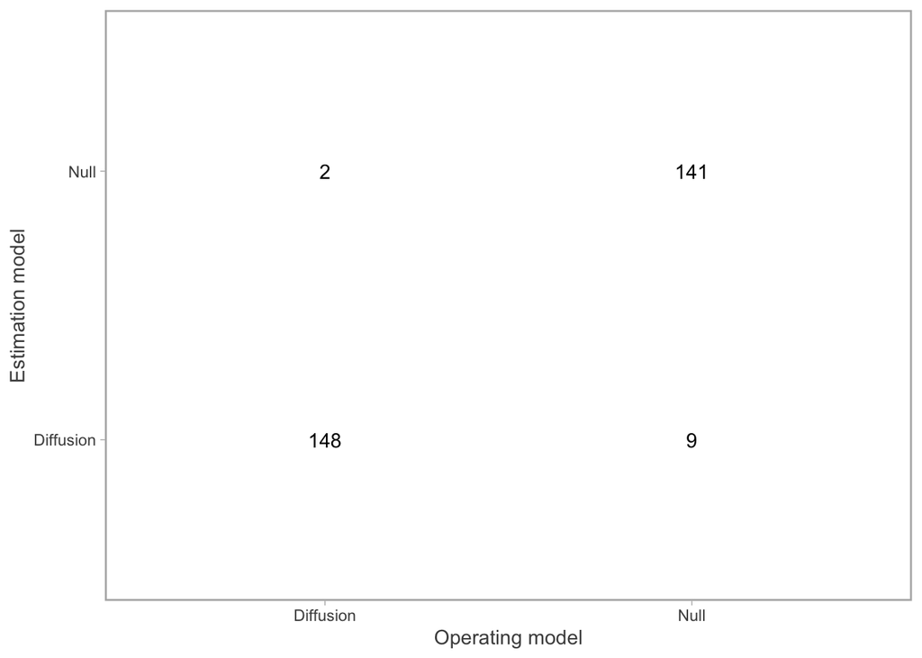

```r
aic_df %>%
  summarise(count = sum(aic),
            .by = c(`Operating model`, `Estimation model`)) %>%
  ggplot(aes(`Operating model`, `Estimation model`, label = count)) +
  geom_text()
```

```r
ggsave(paste0(here::here(), "/results/simulation/confusion_table.pdf"), width = 11, height = 11, unit = "cm")
```

How does AIC difference between the estimation models and diffusion operating model change with ln_kappa?

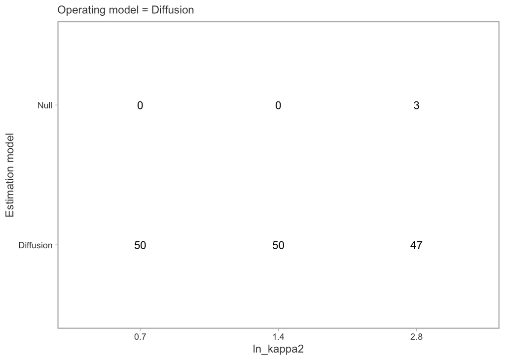

```r
aic_df_kappa %>%
  separate_wider_delim(index, delim = "-", names = c("iter", "ln_sigma_eta", "ln_kappa2")) %>%
  filter(ln_sigma_eta == median(as.numeric(ln_sigma_eta))) %>% # Because we have
  summarise(count = sum(aic),
            .by = c(`Estimation model`, ln_kappa2)) %>%
  ggplot(aes(ln_kappa2, `Estimation model`, label = count)) +
  geom_text() +
  ggtitle("Operating model = Diffusion")
```

```r
ggsave(paste0(here::here(), "/results/simulation/confusion_table_kappa.pdf"), width = 11, height = 11, unit = "cm")
```

Plot how well the models can retrieve the true depth coefficients

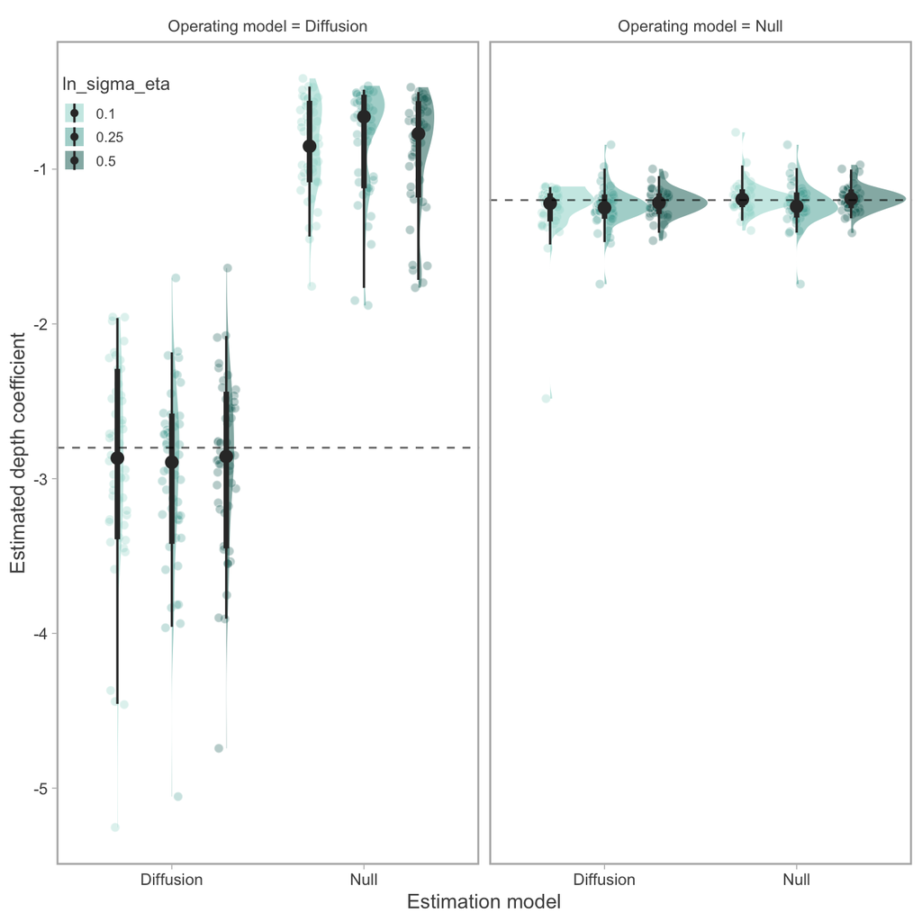

```r
# True values (horizontal lines)
true <- tibble(value = c(as.numeric(p_sim_diff[names(p_sim_diff) == "beta_j"]),
                         as.numeric(p_sim_null[names(p_sim_null) == "beta_j"])),
               par = c("beta[j1]"),
               `Operating model` = c("Operating model = Diffusion",
                                     "Operating model = Null"),
               )

pal <- colorRampPalette(brewer.pal(10, "BrBG"))(20)[c(13, 15, 18)]

ggplot(pars_df, aes(`Estimation model`, est, fill = ln_sigma_eta, color = ln_sigma_eta)) +
  geom_jitter(position = position_jitterdodge(dodge.width = 0.85, jitter.width = 0.1, jitter.height = 0),
              alpha = 0.3, shape = 21, color = "white", size = 2) +
  stat_halfeye(alpha = 0.5, color = NA, position = position_dodge(width = 0.85)) +
  stat_pointinterval(position = position_dodge(width = 0.85), color = "grey20") +
  labs(y = "Estimated depth coefficient", x = "Estimation model") +
  geom_hline(data = true, aes(yintercept = value),
             alpha = 0.6, linetype = 2) +
  facet_wrap(~`Operating model`, ncol = 2) +
  scale_color_manual(values = pal, name = "") +
  scale_fill_manual(values = pal, name = "ln_sigma_eta") +
  guides(color = "none", fill = guide_legend(position = "inside")) +
  theme(legend.position.inside = c(0.07, 0.9))
```

```r
ggsave(paste0(here::here(), "/results/simulation/sims.pdf"), width = 20, height = 13, unit = "cm")
```

Plot how well the models can retrieve the true depth coefficients (and kappa) with kappa variation and only the diffusion OM

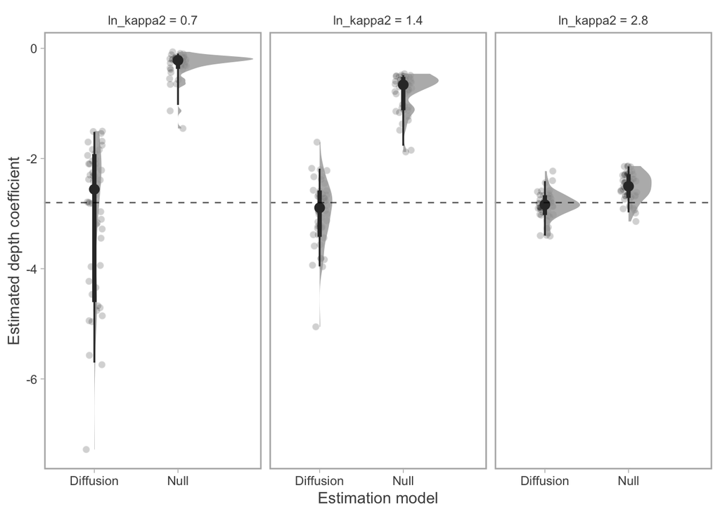

```r
# True values (horizontal lines)
true <- tibble(value = as.numeric(p_sim_diff[names(p_sim_diff) == "beta_j"]),
               par = c("beta[j1]"))

pars_df_kappa2 <- pars_df_kappa %>% filter(par == "beta[j1]" & ln_sigma_eta == 0.25) %>%
  mutate(ln_kappa2 = ifelse(ln_kappa2 == 0.7, "ln_kappa2 = 0.7", ln_kappa2),
         ln_kappa2 = ifelse(ln_kappa2 == 1.4, "ln_kappa2 = 1.4", ln_kappa2),
         ln_kappa2 = ifelse(ln_kappa2 == 2.8, "ln_kappa2 = 2.8", ln_kappa2))

# Depth coefficients
ggplot(pars_df_kappa2, aes(`Estimation model`, est)) +
  geom_jitter(alpha = 0.2, shape = 21, color = "white", fill = "grey10", size = 2, height = 0, width = 0.1) +
  stat_halfeye(alpha = 0.8, color = NA) +
  stat_pointinterval(color = "grey20") +
  labs(y = "Estimated depth coefficient", x = "Estimation model") +
  geom_hline(data = true, aes(yintercept = value),
             alpha = 0.6, linetype = 2) +
  facet_wrap(~ln_kappa2, ncol = 3) +
  guides(color = "none", fill = guide_legend(position = "inside")) +
  theme(legend.position.inside = c(0.07, 0.93))
```

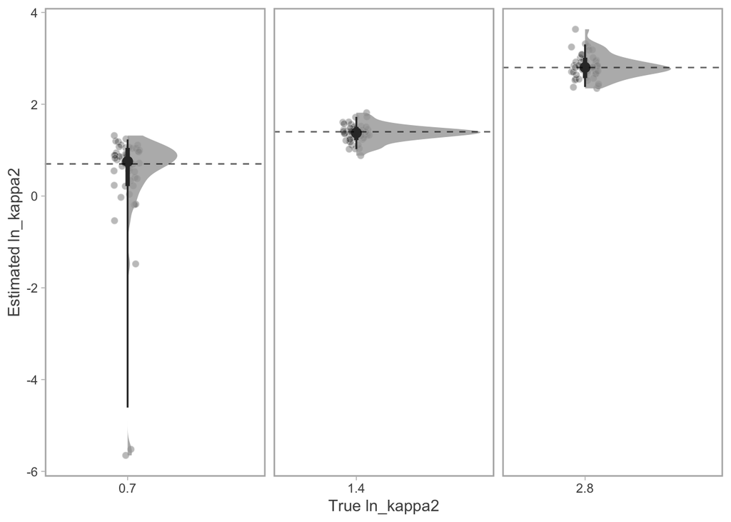

```r
ggsave(paste0(here::here(), "/results/simulation/sims_beta_kappa.pdf"), width = 20, height = 11, unit = "cm")

# How well can we retrieve kappa?
# True values (horizontal lines)
true_kappa <- tibble(ln_kappa2 = c(as.numeric(p_sim_diff[names(p_sim_diff) == "ln_kappa2"]),
                                   as.numeric(p_sim_diff4[names(p_sim_diff4) == "ln_kappa2"]),
                                   as.numeric(p_sim_diff5[names(p_sim_diff5) == "ln_kappa2"])),
                     par = c("ln_kappa2"))

# Depth coefficients
ggplot(pars_df_kappa %>% filter(par == "ln_kappa2" & ln_sigma_eta == 0.25),
       aes(ln_kappa2, est)) +
  geom_jitter(alpha = 0.3, shape = 21, color = "white", fill = "grey10", size = 2, height = 0, width = 0.1) +
  stat_halfeye(alpha = 0.8, color = NA) +
  stat_pointinterval(color = "grey20") +
  labs(y = "Estimated ln_kappa2", x = "True ln_kappa2") +
  geom_hline(data = true_kappa, aes(yintercept = ln_kappa2),
             alpha = 0.6, linetype = 2) +
  guides(color = "none", fill = guide_legend(position = "inside")) +
  facet_wrap(~ln_kappa2, scales = "free_x") +
  theme(legend.position.inside = c(0.09, 0.93),
        strip.background = element_blank(),
        strip.text.x = element_blank())
```

```r
ggsave(paste0(here::here(), "/results/simulation/sims_kappa.pdf"), width = 17, height = 11, unit = "cm")
```